# Prediction Assignment Writeup

V. Bucha

February 12, 2016

# Background

Using devices such as Jawbone Up, Nike FuelBand, and Fitbit it is now possible to collect a large amount of data about personal activity relatively inexpensively. These type of devices are part of the quantified self movement – a group of enthusiasts who take measurements about themselves regularly to improve their health, to find patterns in their behavior, or because they are tech geeks. One thing that people regularly do is quantify how much of a particular activity they do, but they rarely quantify how well they do it. In this project, your goal will be to use data from accelerometers on the belt, forearm, arm, and dumbell of 6 participants. They were asked to perform barbell lifts correctly and incorrectly in 5 different ways. More information is available from the website here: http://groupware.les.inf.puc-rio.br/har (see the section on the Weight Lifting Exercise Dataset).

# Data

The training data for this project are available here:

https://d396qusza40orc.cloudfront.net/predmachlearn/pml-training.csv

The test data are available here:

https://d396qusza40orc.cloudfront.net/predmachlearn/pml-testing.csv

The data for this project come from this source: http://groupware.les.inf.puc-rio.br/har. If you use the document you create for this class for any purpose please cite them as they have been very generous in allowing their data to be used for this kind of assignment.

# Data read and cleaning

Raw training data have feilds with values equal to “”, “NA” and “#DIV/0!”. Let us fix the issue by converting those values to NA while do data loading. 100 columns have more than 90% of NAs. We will exclude such columns from building the model. We also detected and filtered out variables that are near zero variance predictiors. Finnaly, we removed variables(user_name, timestamps, etc) which do not have predictive power.

```r
suppressMessages(library(caret))
training_raw<-read.table("pml-training.csv",sep=",",header=TRUE,na.strings =c("","NA","#DIV/0!") )
testing_raw<-read.table("pml-testing.csv",sep=",",header=TRUE,na.strings =c("","NA","#DIV/0!"))

DataClean<-function(df){
        #compute NAs percent for each column and select clulums with NAs<90%
        mask<-sapply(df,function(x) {ifelse(sum(is.na(x))/ length(x)>0.9,FALSE,TRUE)})
        training<-df[,mask]

        nzv <- nearZeroVar(training,saveMetrics = TRUE)
        training<-training[,!nzv$nzv]
        #remove first 5 attributes since they do not have predictive power
        training<-training[,-c(1:6)]
}

#apply data cleaning to training and testing data
training<-DataClean(training_raw)
testing<-DataClean(testing_raw)
```

# Model training

Next, training dataset were splited into a 70% training and 30% probing. Parallel random forest method were used to train the model. The error of the model is estimated with a 30% of probing dataset. In order to speed up training step doParallel were set up. It allows to utilize more than one CPUs for calculations. Since we end up with more than acceptable performance of random forest, we do not test more models.

```r
set.seed(123)
inTrain <- createDataPartition(training$classe, p=0.7,list = FALSE)
dfTrain<-training[inTrain,]
dfProbe<-training[-inTrain,]
#load libraries for parallel training utilizing several CPU cores
suppressMessages(library(doParallel))

#register doParallel
registerDoParallel()

#fit random forest model
#modelFit <- train(classe ~ ., data = dfTrain,  method="parRF", tuneGrid=data.frame(mtry=5), trControl=trainControl(method="none"))
modelFit <- train(classe ~ ., data = dfTrain,  method="parRF", tuneGrid=data.frame(mtry=5),trControl=trainControl(method='cv'))
```

# Final model

Random forests can evaluate the attributes importance and their impact on classification. We showed only top 20 the most important variables.

```r
modelFit
```

```
## Parallel Random Forest
##
## 13737 samples
##    52 predictor
##     5 classes: 'A', 'B', 'C', 'D', 'E'
##
## No pre-processing
## Resampling: Cross-Validated (10 fold)
## Summary of sample sizes: 12364, 12363, 12363, 12363, 12363, 12364, ...
## Resampling results
##
##   Accuracy   Kappa      Accuracy SD  Kappa SD
##   0.9938125  0.9921731  0.00220324   0.002786819
##
## Tuning parameter 'mtry' was held constant at a value of 5
##
```

```r
modelFit$finalModel
```

```
##
## Call:
##  randomForest(x = "x", y = "y", ntree = 125, mtry = 5)
##                Type of random forest: classification
##                      Number of trees: 250
## No. of variables tried at each split: 5
```

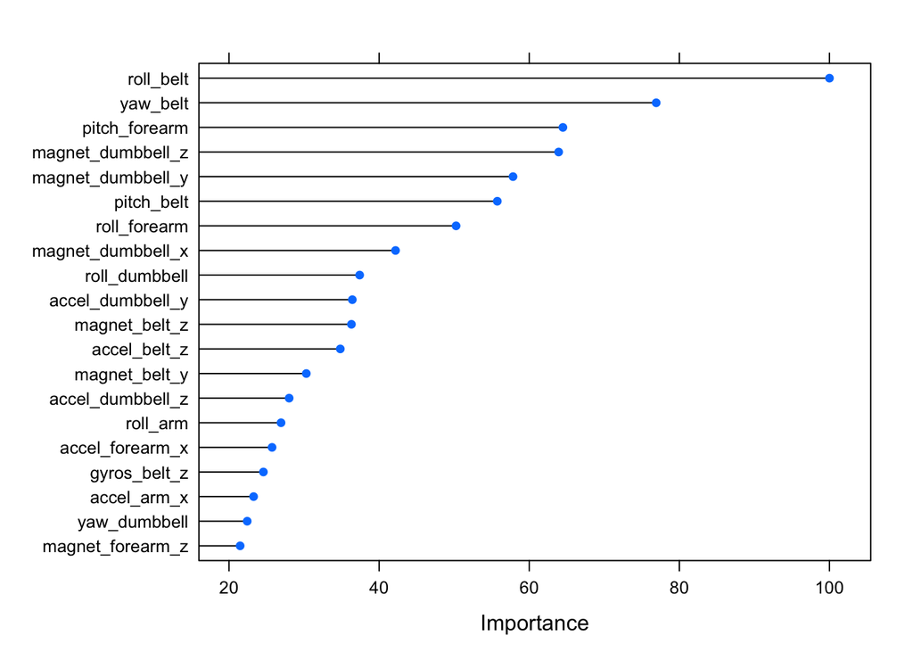

```r
plot(varImp(modelFit),top=20)
```

# Evaluate the model on training data

This model get 100% accuracy on training data. Out of sample error will be checked on probing 30% data.

```r
modelFit
```

```
## Parallel Random Forest
##
## 13737 samples
##    52 predictor
##     5 classes: 'A', 'B', 'C', 'D', 'E'
##
## No pre-processing
## Resampling: Cross-Validated (10 fold)
## Summary of sample sizes: 12364, 12363, 12363, 12363, 12363, 12364, ...
## Resampling results
##
##   Accuracy   Kappa      Accuracy SD  Kappa SD
##   0.9938125  0.9921731  0.00220324   0.002786819
##
## Tuning parameter 'mtry' was held constant at a value of 5
##
```

```r
hat <- predict(modelFit, dfTrain)
confusionMatrix(hat, dfTrain$classe)
```

```
## Confusion Matrix and Statistics
##
##           Reference
## Prediction    A    B    C    D    E
##          A 3906    0    0    0    0
##          B    0 2658    0    0    0
##          C    0    0 2396    0    0
##          D    0    0    0 2252    0
##          E    0    0    0    0 2525
##
## Overall Statistics
##
##                Accuracy : 1
##                  95% CI : (0.9997, 1)
##     No Information Rate : 0.2843
##     P-Value [Acc > NIR] : < 2.2e-16
##
##                   Kappa : 1
##  Mcnemar's Test P-Value : NA
##
## Statistics by Class:
##
##                      Class: A Class: B Class: C Class: D Class: E
## Sensitivity            1.0000   1.0000   1.0000   1.0000   1.0000
## Specificity            1.0000   1.0000   1.0000   1.0000   1.0000
## Pos Pred Value         1.0000   1.0000   1.0000   1.0000   1.0000
## Neg Pred Value         1.0000   1.0000   1.0000   1.0000   1.0000
## Prevalence             0.2843   0.1935   0.1744   0.1639   0.1838
## Detection Rate         0.2843   0.1935   0.1744   0.1639   0.1838
## Detection Prevalence   0.2843   0.1935   0.1744   0.1639   0.1838
## Balanced Accuracy      1.0000   1.0000   1.0000   1.0000   1.0000
```

# Evaluate the model on test data

This model is accurate as we can see in the consusion matrix. Accuracy: ~99 is a very accurate estimate.

```r
hat <- predict(modelFit, dfProbe)
confusionMatrix(hat, dfProbe$classe)
```

```
## Confusion Matrix and Statistics
##
##           Reference
## Prediction    A    B    C    D    E
##          A 1672    7    0    0    0
##          B    1 1132   12    0    0
##          C    0    0 1014   16    0
##          D    0    0    0  947    0
##          E    1    0    0    1 1082
##
## Overall Statistics
##
##                Accuracy : 0.9935
##                  95% CI : (0.9911, 0.9954)
##     No Information Rate : 0.2845
##     P-Value [Acc > NIR] : < 2.2e-16
##
##                   Kappa : 0.9918
##  Mcnemar's Test P-Value : NA
##
## Statistics by Class:
##
##                      Class: A Class: B Class: C Class: D Class: E
## Sensitivity            0.9988   0.9939   0.9883   0.9824   1.0000
## Specificity            0.9983   0.9973   0.9967   1.0000   0.9996
## Pos Pred Value         0.9958   0.9886   0.9845   1.0000   0.9982
## Neg Pred Value         0.9995   0.9985   0.9975   0.9966   1.0000
## Prevalence             0.2845   0.1935   0.1743   0.1638   0.1839
## Detection Rate         0.2841   0.1924   0.1723   0.1609   0.1839
## Detection Prevalence   0.2853   0.1946   0.1750   0.1609   0.1842
## Balanced Accuracy      0.9986   0.9956   0.9925   0.9912   0.9998
```

# Predict on the assignment test data

Finally, we apply the model to the 20 unlabeled assignment cases.

```r
hat <- predict(modelFit, testing)
hat
```

```
##  [1] B A B A A E D B A A B C B A E E A B B B
## Levels: A B C D E
```